# IPL EDA

Sreerag M S

12/04/2022

## Loading necessary packages

```r
library(tidyverse)
```

# Load the dataset

```r
ipl_matches <- read.csv("IPL Matches 2008-2020.csv")
```

## Lets take a look at what we have here

```r
str(ipl_matches)
```

```
## 'data.frame':    816 obs. of  18 variables:
##  $ id             : int  335982 335983 335984 335985 335986 335987 335988 335989 335990 335991 ...
##  $ city           : chr  "Bangalore" "Chandigarh" "Delhi" "Mumbai" ...
##  $ date           : chr  "18-04-2008" "19-04-2008" "19-04-2008" "20-04-2008" ...
##  $ player_of_match: chr  "BB McCullum" "MEK Hussey" "MF Maharoof" "MV Boucher" ...
##  $ venue          : chr  "M Chinnaswamy Stadium" "Punjab Cricket Association Stadium, Mohali" "Feroz Shah Kotla" "Wankhede Stadium" ...
##  $ neutral_venue  : int  0 0 0 0 0 0 0 0 0 0 ...
##  $ team1          : chr  "Royal Challengers Bangalore" "Kings XI Punjab" "Delhi Daredevils" "Mumbai Indians" ...
##  $ team2          : chr  "Kolkata Knight Riders" "Chennai Super Kings" "Rajasthan Royals" "Royal Challengers Bangalore" ...
##  $ toss_winner    : chr  "Royal Challengers Bangalore" "Chennai Super Kings" "Rajasthan Royals" "Mumbai Indians" ...
##  $ toss_decision  : chr  "field" "bat" "bat" "bat" ...
##  $ winner         : chr  "Kolkata Knight Riders" "Chennai Super Kings" "Delhi Daredevils" "Royal Challengers Bangalore" ...
##  $ result         : chr  "runs" "runs" "wickets" "wickets" ...
##  $ result_margin  : int  140 33 9 5 5 6 9 6 3 66 ...
##  $ eliminator     : chr  "N" "N" "N" "N" ...
##  $ method         : chr  NA NA NA NA ...
##  $ umpire1        : chr  "Asad Rauf" "MR Benson" "Aleem Dar" "SJ Davis" ...
##  $ umpire2        : chr  "RE Koertzen" "SL Shastri" "GA Pratapkumar" "DJ Harper" ...
##  $ loser          : chr  "Royal Challengers Bangalore" "Kings XI Punjab" "Rajasthan Royals" "Mumbai Indians" ...
```

## Lets see first few rows

```r
head(ipl_matches,10)
```

```
##        id       city       date player_of_match
## 1  335982  Bangalore 18-04-2008     BB McCullum
## 2  335983 Chandigarh 19-04-2008      MEK Hussey
## 3  335984      Delhi 19-04-2008     MF Maharoof
## 4  335985     Mumbai 20-04-2008      MV Boucher
## 5  335986    Kolkata 20-04-2008       DJ Hussey
## 6  335987     Jaipur 21-04-2008       SR Watson
## 7  335988  Hyderabad 22-04-2008        V Sehwag
## 8  335989    Chennai 23-04-2008       ML Hayden
## 9  335990  Hyderabad 24-04-2008       YK Pathan
## 10 335991 Chandigarh 25-04-2008   KC Sangakkara
##                                         venue neutral_venue
## 1                       M Chinnaswamy Stadium             0
## 2  Punjab Cricket Association Stadium, Mohali             0
## 3                            Feroz Shah Kotla             0
```

[output cut: 51 more lines]

## Now for the last few matches

```r
tail(ipl_matches,10)
```

```
##          id      city       date player_of_match
## 807 1216542     Dubai 08-10-2020     JM Bairstow
## 808 1216543     Dubai 14-10-2020        A Nortje
## 809 1216544     Dubai 25-10-2020      RD Gaikwad
## 810 1216545 Abu Dhabi 26-09-2020    Shubman Gill
## 811 1216546     Dubai 20-10-2020        S Dhawan
## 812 1216547     Dubai 28-09-2020  AB de Villiers
## 813 1237177     Dubai 05-11-2020       JJ Bumrah
## 814 1237178 Abu Dhabi 06-11-2020   KS Williamson
## 815 1237180 Abu Dhabi 08-11-2020      MP Stoinis
## 816 1237181     Dubai 10-11-2020        TA Boult
##                                   venue neutral_venue
## 807 Dubai International Cricket Stadium             0
## 808 Dubai International Cricket Stadium             0
## 809 Dubai International Cricket Stadium             0
```

[output cut: 51 more lines]

Lets look at the column names

```r
colnames(ipl_matches)
```

```
##  [1] "id"              "city"            "date"            "player_of_match"
##  [5] "venue"           "neutral_venue"   "team1"           "team2"
##  [9] "toss_winner"     "toss_decision"   "winner"          "result"
## [13] "result_margin"   "eliminator"      "method"          "umpire1"
## [17] "umpire2"         "loser"
```

## Plotting a graph to see the number of matches won by each team

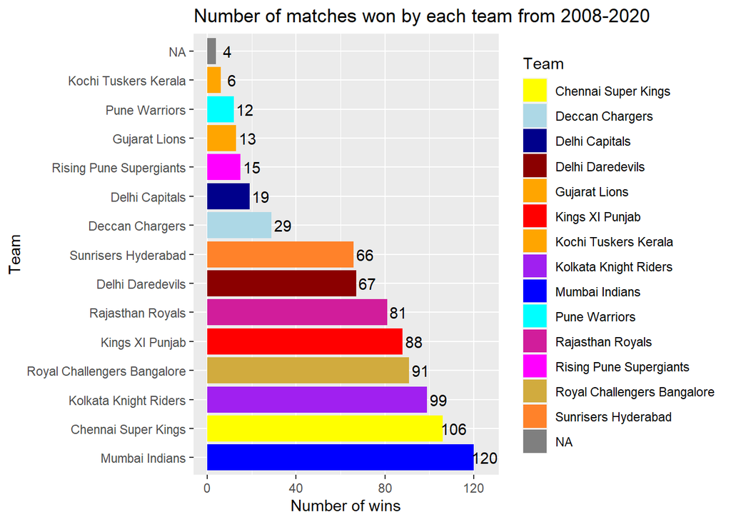

```r
plt <- ggplot(data = ipl_matches) +
  geom_bar(mapping = aes(y = fct_infreq(winner), fill = winner))
plot_data <- layer_data(plt)
plt + annotate(geom = "text", label = plot_data$count, x = plot_data$x +5, y = plot_data$y ) +
  scale_fill_manual(values = c("yellow","lightblue","#00008B","darkred","orange","red","orange","purple","blue","cyan","#D11D9B","magenta","#D1AB3E","#FF822A","grey")) +
  labs(title = "Number of matches won by each team from 2008-2020", x = "Number of wins", y = "Team") +
  guides(fill=guide_legend(title="Team"))
```

```r
  #geom_vline(xintercept = mean(plot_data$x),colour = "black")
```

## Now lets take a look at the number of loses by each team

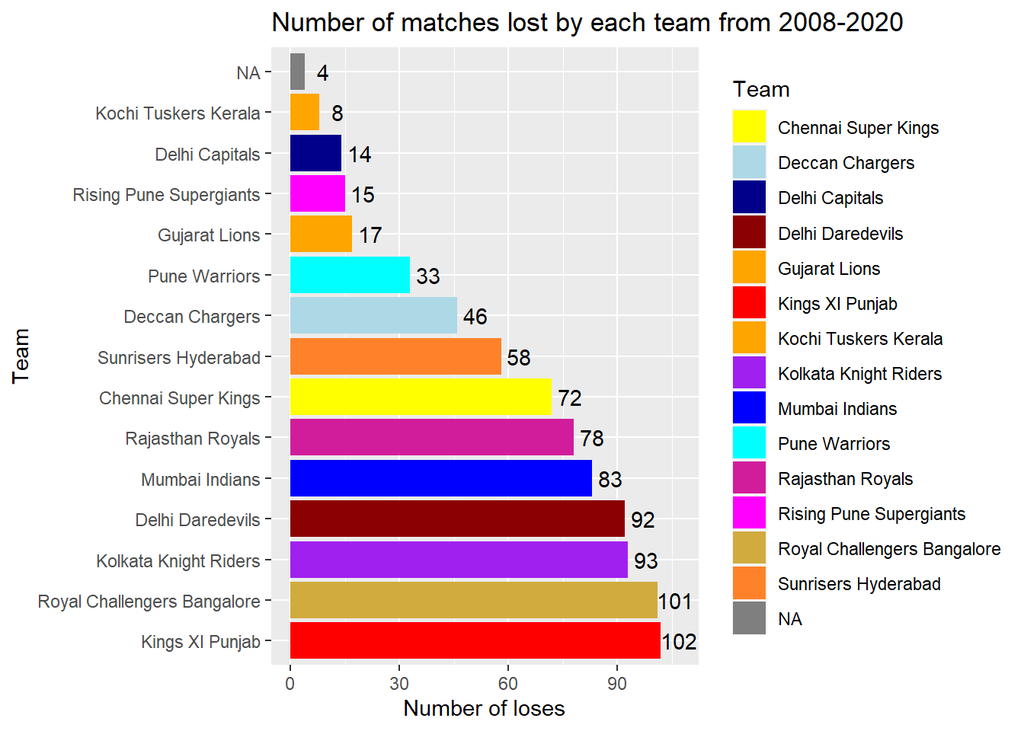

```r
plt <- ggplot(data = ipl_matches) +
  geom_bar(mapping = aes(y = fct_infreq(loser), fill = loser))
plot_data <- layer_data(plt)
plt + annotate(geom = "text", label = plot_data$count, x = plot_data$x +5, y = plot_data$y ) +
  scale_fill_manual(values = c("yellow","lightblue","#00008B","darkred","orange","red","orange","purple","blue","cyan","#D11D9B","magenta","#D1AB3E","#FF822A","grey")) +
  labs(title = "Number of matches lost by each team from 2008-2020", x = "Number of loses", y = "Team") +
  guides(fill=guide_legend(title="Team"))
```

## Lets see which players have been man of the match most number of times

```r
ipl_matches %>%
  count(player_of_match,sort = TRUE,name = "Number of MOTMs") %>%
  top_n(15)
```

```
##    player_of_match Number of MOTMs
## 1   AB de Villiers              23
## 2         CH Gayle              22
## 3        RG Sharma              18
## 4        DA Warner              17
## 5         MS Dhoni              17
## 6        SR Watson              16
## 7        YK Pathan              16
## 8         SK Raina              14
## 9        G Gambhir              13
## 10         V Kohli              13
## 11       AM Rahane              12
## 12      MEK Hussey              12
## 13        A Mishra              11
## 14      AD Russell              11
## 15        DR Smith              11
## 16      KA Pollard              11
## 17        V Sehwag              11
```

## Interesting… ABD who has got the most MOTMs has never won an IPL title along with Chris Gayle, Virat Kohli, Ajinkya Rahane and Amit Mishra.

```r
ipl_matches %>%
  count(toss_decision)
```

```
##   toss_decision   n
## 1           bat 320
## 2         field 496
```

## Importing another dataset from the same time period(2008-2020) for further analysis

```r
ipl_ball_by_ball <- read.csv("IPL Ball-by-Ball 2008-2020.csv")
```

## Inspecting the dataset

```r
str(ipl_ball_by_ball)
```

```
## 'data.frame':    193468 obs. of  18 variables:
##  $ id              : int  335982 335982 335982 335982 335982 335982 335982 335982 335982 335982 ...
##  $ inning          : int  1 1 1 1 1 1 1 1 1 1 ...
##  $ over            : int  6 6 7 7 7 7 7 7 8 8 ...
##  $ ball            : int  5 6 1 2 3 4 5 6 1 2 ...
##  $ batsman         : chr  "RT Ponting" "BB McCullum" "BB McCullum" "BB McCullum" ...
##  $ non_striker     : chr  "BB McCullum" "RT Ponting" "RT Ponting" "RT Ponting" ...
##  $ bowler          : chr  "AA Noffke" "AA Noffke" "Z Khan" "Z Khan" ...
##  $ batsman_runs    : int  1 1 0 1 1 1 1 1 0 0 ...
##  $ extra_runs      : int  0 0 0 0 0 0 0 0 0 0 ...
##  $ total_runs      : int  1 1 0 1 1 1 1 1 0 0 ...
##  $ non_boundary    : int  0 0 0 0 0 0 0 0 0 0 ...
##  $ is_wicket       : int  0 0 0 0 0 0 0 0 0 0 ...
##  $ dismissal_kind  : chr  NA NA NA NA ...
##  $ player_dismissed: chr  NA NA NA NA ...
##  $ fielder         : chr  NA NA NA NA ...
##  $ extras_type     : chr  NA NA NA NA ...
##  $ batting_team    : chr  "Kolkata Knight Riders" "Kolkata Knight Riders" "Kolkata Knight Riders" "Kolkata Knight Riders" ...
##  $ bowling_team    : chr  "Royal Challengers Bangalore" "Royal Challengers Bangalore" "Royal Challengers Bangalore" "Royal Challengers Bangalore" ...
```

```r
colnames(ipl_ball_by_ball)
```

```
##  [1] "id"               "inning"           "over"             "ball"
##  [5] "batsman"          "non_striker"      "bowler"           "batsman_runs"
##  [9] "extra_runs"       "total_runs"       "non_boundary"     "is_wicket"
## [13] "dismissal_kind"   "player_dismissed" "fielder"          "extras_type"
## [17] "batting_team"     "bowling_team"
```

```r
head(ipl_ball_by_ball)
```

```
##       id inning over ball     batsman non_striker    bowler batsman_runs
## 1 335982      1    6    5  RT Ponting BB McCullum AA Noffke            1
## 2 335982      1    6    6 BB McCullum  RT Ponting AA Noffke            1
## 3 335982      1    7    1 BB McCullum  RT Ponting    Z Khan            0
## 4 335982      1    7    2 BB McCullum  RT Ponting    Z Khan            1
## 5 335982      1    7    3  RT Ponting BB McCullum    Z Khan            1
## 6 335982      1    7    4 BB McCullum  RT Ponting    Z Khan            1
##   extra_runs total_runs non_boundary is_wicket dismissal_kind player_dismissed
## 1          0          1            0         0           <NA>             <NA>
## 2          0          1            0         0           <NA>             <NA>
## 3          0          0            0         0           <NA>             <NA>
## 4          0          1            0         0           <NA>             <NA>
## 5          0          1            0         0           <NA>             <NA>
## 6          0          1            0         0           <NA>             <NA>
##   fielder extras_type          batting_team                bowling_team
## 1    <NA>        <NA> Kolkata Knight Riders Royal Challengers Bangalore
## 2    <NA>        <NA> Kolkata Knight Riders Royal Challengers Bangalore
## 3    <NA>        <NA> Kolkata Knight Riders Royal Challengers Bangalore
## 4    <NA>        <NA> Kolkata Knight Riders Royal Challengers Bangalore
## 5    <NA>        <NA> Kolkata Knight Riders Royal Challengers Bangalore
## 6    <NA>        <NA> Kolkata Knight Riders Royal Challengers Bangalore
```

```r
tail(ipl_ball_by_ball)
```

```
##             id inning over ball batsman non_striker          bowler
## 193463 1237181      1   12    4 SS Iyer     RR Pant NM Coulter-Nile
## 193464 1237181      1   12    5 RR Pant     SS Iyer NM Coulter-Nile
## 193465 1237181      1   12    6 RR Pant     SS Iyer NM Coulter-Nile
## 193466 1237181      1   13    1 RR Pant     SS Iyer       KH Pandya
## 193467 1237181      1   13    2 RR Pant     SS Iyer       KH Pandya
## 193468 1237181      1   13    3 SS Iyer     RR Pant       KH Pandya
##        batsman_runs extra_runs total_runs non_boundary is_wicket dismissal_kind
## 193463            1          0          1            0         0           <NA>
## 193464            0          0          0            0         0           <NA>
## 193465            1          0          1            0         0           <NA>
## 193466            0          1          1            0         0           <NA>
## 193467            1          0          1            0         0           <NA>
## 193468            1          0          1            0         0           <NA>
##        player_dismissed fielder extras_type   batting_team   bowling_team
## 193463             <NA>    <NA>        <NA> Delhi Capitals Mumbai Indians
## 193464             <NA>    <NA>        <NA> Delhi Capitals Mumbai Indians
## 193465             <NA>    <NA>        <NA> Delhi Capitals Mumbai Indians
## 193466             <NA>    <NA>       wides Delhi Capitals Mumbai Indians
## 193467             <NA>    <NA>        <NA> Delhi Capitals Mumbai Indians
## 193468             <NA>    <NA>        <NA> Delhi Capitals Mumbai Indians
```

The matches in the data seems to be in order but the overs are not in order.

## Lets try to find some insights from this

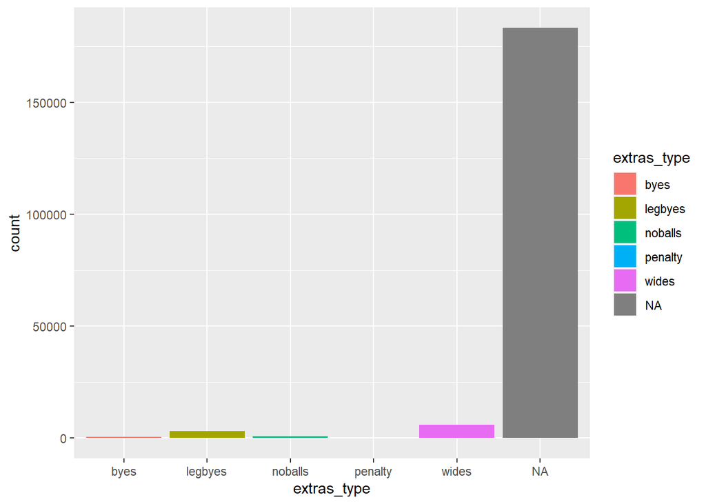

```r
  ggplot(data = ipl_ball_by_ball) +
  geom_bar(mapping = aes(x = extras_type, fill = extras_type))
```

## This graph doesnt work as most of the balls are not extras, so we drop the NAs.

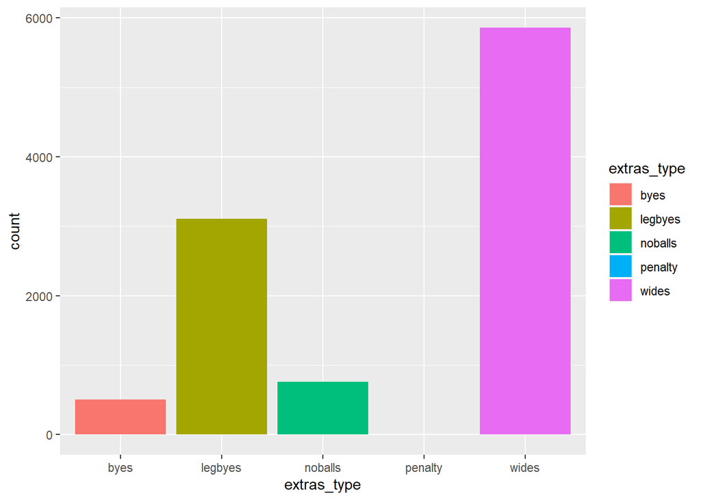

```r
ipl_ball_by_ball %>%
  filter(!is.na(extras_type)) %>%
  ggplot(aes(x = extras_type,fill = extras_type)) +
  geom_bar()
```

## Still the value for penalty seems very small compared to others,lets try labelling it.

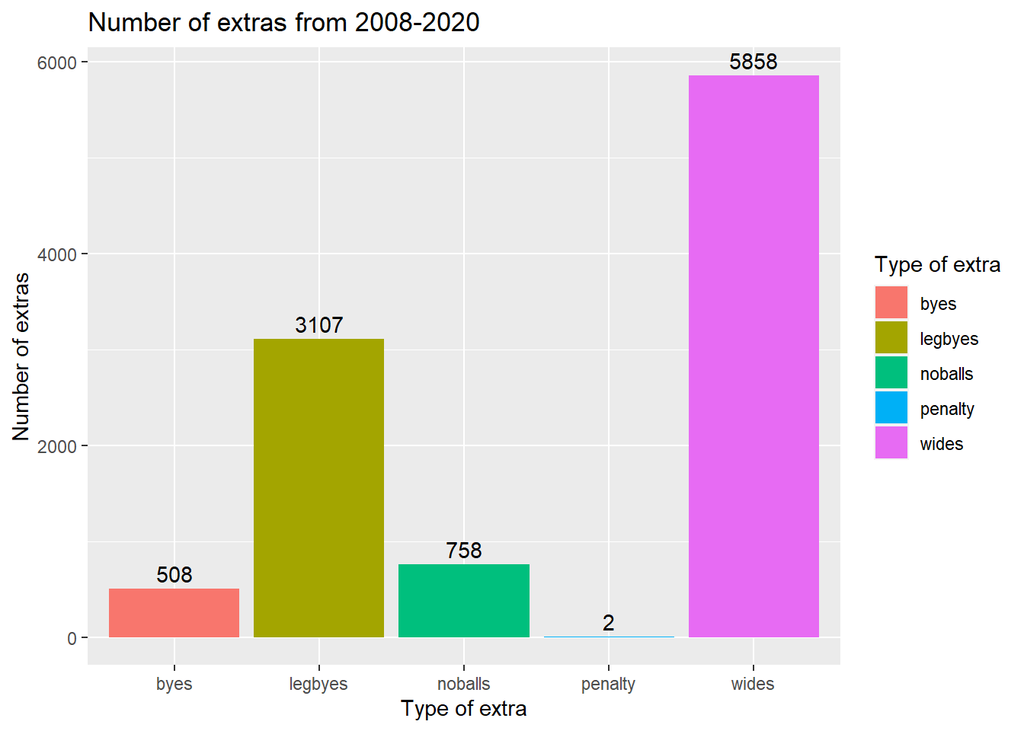

```r
ipl_ball_by_ball %>%
  filter(!is.na(extras_type)) %>%
  ggplot(aes(x = extras_type,fill = extras_type)) +
  geom_bar() +
  geom_text(aes(label = ..count..), stat = "count", vjust = -0.4) +
  labs(title = "Number of extras from 2008-2020", x = "Type of extra", y = "Number of extras") +
  guides(fill=guide_legend(title="Type of extra"))
```

### And yes, there were 2 penalties.

## Trying to create a circular bar chart of runs scored in each(20) over.

```r
over_data <- ipl_ball_by_ball %>%
  group_by(over) %>%
  summarise(runs_in_overs = sum(total_runs))

over_data
```

```
## # A tibble: 20 × 2
##     over runs_in_overs
##    <int>         <int>
##  1     0          9804
##  2     1         11642
##  3     2         13005
##  4     3         13348
##  5     4         13405
##  6     5         13470
##  7     6         10840
##  8     7         11548
##  9     8         11999
## 10     9         11875
## 11    10         12199
## 12    11         12458
## 13    12         12542
## 14    13         12897
## 15    14         13326
## 16    15         13449
## 17    16         13989
## 18    17         14307
## 19    18         13804
## 20    19         12887
```

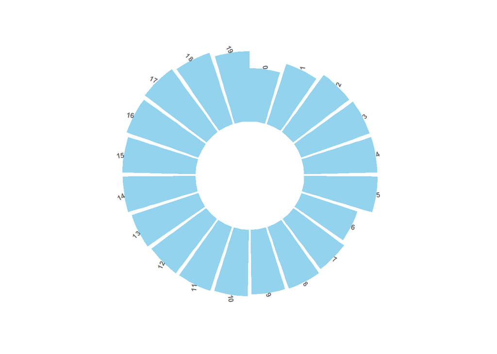

```r
label_data <- over_data

number_of_bar <- nrow(label_data)

# calculate the ANGLE of the labels
angle <-  90 - 360 * (label_data$over-0.5) /number_of_bar

# calculate the alignment of labels: right or left
# If I am on the left part of the plot, my labels have currently an angle < -90
label_data$hjust<-ifelse( angle < -90, 1, 0)

# flip angle BY to make them readable
label_data$angle<-ifelse(angle < -90, angle+180, angle)

# Start the plot
p <- ggplot(label_data, aes(x=over, y=runs_in_overs)) +       # Note that id is a factor. If x is numeric, there is some space between the first bar

  # This add the bars with a blue color
  geom_bar(stat="identity", fill=alpha("skyblue", 0.9)) +

  # Limits of the plot = very important. The negative value controls the size of the inner circle, the positive one is useful to add size over each bar
  ylim(-10000,20000) +

  # Custom the theme: no axis title and no cartesian grid
  theme_minimal() +
  theme(
    axis.text = element_blank(),
    axis.title = element_blank(),
    panel.grid = element_blank(),
    plot.margin = unit(rep(-1,14), "cm")      # Adjust the margin to make in sort labels are not truncated!
  ) +

  # This makes the coordinate polar instead of cartesian.
  coord_polar(start = 0) +

  # Add the labels, using the label_data dataframe that we have created before
  geom_text(data=label_data, aes(x=over, y=runs_in_overs+10, label=over, hjust=hjust), color="black", fontface="bold",alpha=0.6, size=2.5, angle= label_data$angle, inherit.aes = FALSE )
 p
```

## Plotting total runs scored by batters and runs as extras in each over.

```r
runs_split <- ipl_ball_by_ball %>%
  group_by(over) %>%
  summarise(total_batter_runs = sum(batsman_runs), total_extras = sum(extra_runs))

runs_split_data <- data.frame(runs_split)
runs_split_data
```

```
##    over total_batter_runs total_extras
## 1     0              8894          910
## 2     1             10744          898
## 3     2             12259          746
## 4     3             12674          674
## 5     4             12798          607
## 6     5             12770          700
## 7     6             10205          635
## 8     7             10998          550
## 9     8             11448          551
## 10    9             11344          531
## 11   10             11728          471
## 12   11             11966          492
## 13   12             11956          586
## 14   13             12367          530
## 15   14             12781          545
## 16   15             12864          585
## 17   16             13322          667
## 18   17             13604          703
## 19   18             13082          722
## 20   19             12141          746
```

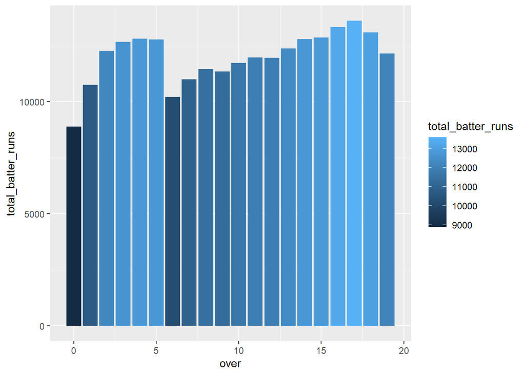

```r
ggplot(data = runs_split_data, aes(fill=total_batter_runs, y=total_batter_runs, x=over)) +
    geom_bar(position="stack", stat="identity")
```

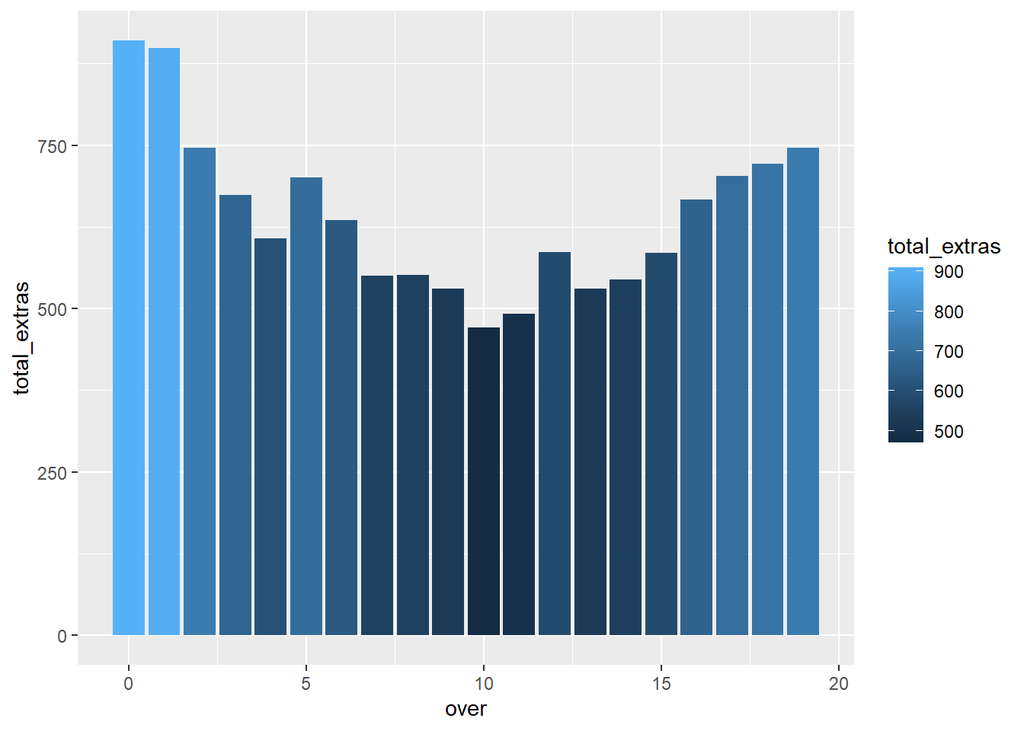

```r
ggplot(data = runs_split_data, aes(fill=total_extras, y=total_extras, x=over)) +
    geom_bar(position="stack", stat="identity")
```

### Trying to normalize the two columns as the range of batter and and extras are different.

```r
normalize <- function(x) {
return ((x - min(x, na.rm = TRUE)) / (max(x, na.rm = TRUE) - min(x, na.rm = TRUE)))}

norm_runs_split <- as.data.frame(apply(runs_split_data[2:3], 2, normalize))
norm_runs_split
```

```
##    total_batter_runs total_extras
## 1          0.0000000   1.00000000
## 2          0.3927813   0.97266515
## 3          0.7144374   0.62642369
## 4          0.8025478   0.46241458
## 5          0.8288747   0.30979499
## 6          0.8229299   0.52164009
## 7          0.2783439   0.37357631
## 8          0.4467091   0.17995444
## 9          0.5422505   0.18223235
## 10         0.5201699   0.13667426
## 11         0.6016985   0.00000000
## 12         0.6522293   0.04783599
## 13         0.6501062   0.26195900
## 14         0.7373673   0.13439636
## 15         0.8252654   0.16856492
## 16         0.8428875   0.25968109
## 17         0.9401274   0.44646925
## 18         1.0000000   0.52847380
## 19         0.8891720   0.57175399
## 20         0.6893843   0.62642369
```

## Plotting the circular bar graph in a different way, just playing around with colour and radius.

```r
overs_data <- ipl_ball_by_ball %>%
  group_by(over) %>%
  summarise(runs_in_overs = sum(total_runs))

dataf<- data.frame(overs_data)
dataf
```

```
##    over runs_in_overs
## 1     0          9804
## 2     1         11642
## 3     2         13005
## 4     3         13348
## 5     4         13405
## 6     5         13470
## 7     6         10840
## 8     7         11548
## 9     8         11999
## 10    9         11875
## 11   10         12199
## 12   11         12458
## 13   12         12542
## 14   13         12897
## 15   14         13326
## 16   15         13449
## 17   16         13989
## 18   17         14307
## 19   18         13804
## 20   19         12887
```

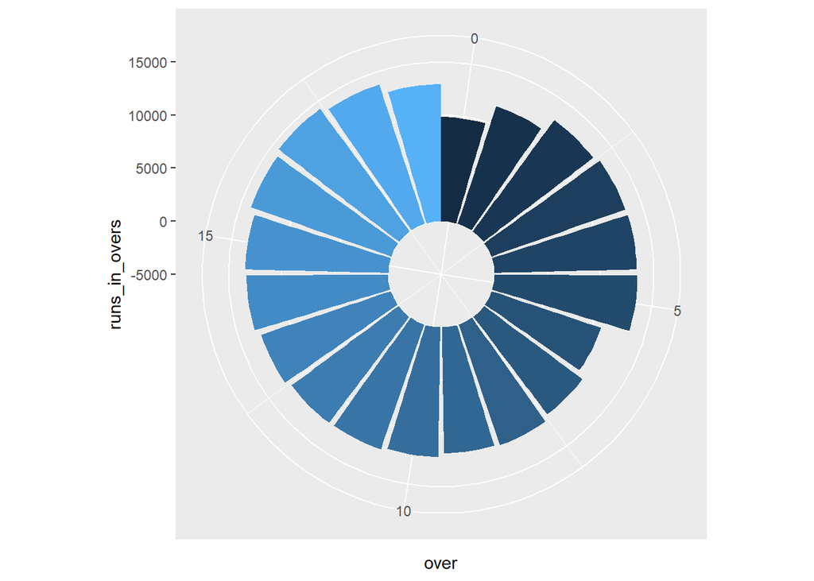

```r
ggplot(dataf,aes(x=over,y=runs_in_overs,fill = over)) +
  geom_bar(stat = "identity") +
  theme(legend.position = "none") +
  ylim(-5000,15000) +
  coord_polar(start=0)
```